# Project: European Soccer Database

- Introduction
- Data Wrangling
- Exploratory Data Analysis
- Conclusions

## Introduction

> In this project I will analyze the soccer database from several European countries, from 2008 to 2016. The data has been downloaded via SQLite and merged inside the tool using JOINs.

> Questions: Which are the top 3 leagues that had the most wins during 2008-2016? Which teams in the 3 leagues won most of the games? Who is the most rated player? What are the attributes that contribute to the players' overall rating? What team attributes lead to the most victories?

```python
#import packages
import pandas as pd
import numpy as np
import matplotlib.pyplot as plt
% matplotlib inline
```

## Data Wrangling

### General Properties

```python
# Load your data and print out a few lines. Perform operations to inspect data
#   types and look for instances of missing or possibly errant data.
df_m = pd.read_csv('Matches.csv')
df_p = pd.read_csv('Players.csv')
df_t = pd.read_csv('Teams.csv')
```

```python
#view first lines of Matches
df_m.head()
```

|  | Country | League | season | date | home_team_api_id | away_team_api_id | home_team_goal | away_team_goal | goal | shoton | shotoff | foulcommit | card | cross | corner | possession |
| --- | --- | --- | --- | --- | --- | --- | --- | --- | --- | --- | --- | --- | --- | --- | --- | --- |
| 0 | Belgium | Belgium Jupiler League | 2008/2009 | 2008-08-16 00:00:00 | 4049 | 9996 | 1 | 2 | NaN | NaN | NaN | NaN | NaN | NaN | NaN | NaN |
| 1 | Belgium | Belgium Jupiler League | 2008/2009 | 2008-08-16 00:00:00 | 7947 | 9985 | 1 | 3 | NaN | NaN | NaN | NaN | NaN | NaN | NaN | NaN |
| 2 | Belgium | Belgium Jupiler League | 2008/2009 | 2008-08-16 00:00:00 | 9984 | 8635 | 0 | 3 | NaN | NaN | NaN | NaN | NaN | NaN | NaN | NaN |
| 3 | Belgium | Belgium Jupiler League | 2008/2009 | 2008-08-16 00:00:00 | 9999 | 8571 | 2 | 2 | NaN | NaN | NaN | NaN | NaN | NaN | NaN | NaN |
| 4 | Belgium | Belgium Jupiler League | 2008/2009 | 2008-08-16 00:00:00 | 10000 | 9994 | 0 | 0 | NaN | NaN | NaN | NaN | NaN | NaN | NaN | NaN |

```python
#view first lines of Players
df_p.head()
```

|  | player_name | birthday | height | weight | id | player_fifa_api_id | player_api_id | date | overall_rating | potential | ... | vision | penalties | marking | standing_tackle | sliding_tackle | gk_diving | gk_handling | gk_kicking | gk_positioning | gk_reflexes |
| --- | --- | --- | --- | --- | --- | --- | --- | --- | --- | --- | --- | --- | --- | --- | --- | --- | --- | --- | --- | --- | --- |
| 0 | Aaron Appindangoye | 1992-02-29 00:00:00 | 182.88 | 187 | 1 | 218353 | 505942 | 2016-02-18 00:00:00 | 67.0 | 71.0 | ... | 54.0 | 48.0 | 65.0 | 69.0 | 69.0 | 6.0 | 11.0 | 10.0 | 8.0 | 8.0 |
| 1 | Aaron Cresswell | 1989-12-15 00:00:00 | 170.18 | 146 | 2 | 218353 | 505942 | 2015-11-19 00:00:00 | 67.0 | 71.0 | ... | 54.0 | 48.0 | 65.0 | 69.0 | 69.0 | 6.0 | 11.0 | 10.0 | 8.0 | 8.0 |
| 2 | Aaron Doran | 1991-05-13 00:00:00 | 170.18 | 163 | 3 | 218353 | 505942 | 2015-09-21 00:00:00 | 62.0 | 66.0 | ... | 54.0 | 48.0 | 65.0 | 66.0 | 69.0 | 6.0 | 11.0 | 10.0 | 8.0 | 8.0 |
| 3 | Aaron Galindo | 1982-05-08 00:00:00 | 182.88 | 198 | 4 | 218353 | 505942 | 2015-03-20 00:00:00 | 61.0 | 65.0 | ... | 53.0 | 47.0 | 62.0 | 63.0 | 66.0 | 5.0 | 10.0 | 9.0 | 7.0 | 7.0 |
| 4 | Aaron Hughes | 1979-11-08 00:00:00 | 182.88 | 154 | 5 | 218353 | 505942 | 2007-02-22 00:00:00 | 61.0 | 65.0 | ... | 53.0 | 47.0 | 62.0 | 63.0 | 66.0 | 5.0 | 10.0 | 9.0 | 7.0 | 7.0 |

5 rows × 46 columns

```python
#view first lines of Teams
df_t.head()
```

|  | team_short_name | team_long_name | id | team_fifa_api_id | team_api_id | date | buildUpPlaySpeed | buildUpPlaySpeedClass | buildUpPlayDribbling | buildUpPlayDribblingClass | ... | chanceCreationShooting | chanceCreationShootingClass | chanceCreationPositioningClass | defencePressure | defencePressureClass | defenceAggression | defenceAggressionClass | defenceTeamWidth | defenceTeamWidthClass | defenceDefenderLineClass |
| --- | --- | --- | --- | --- | --- | --- | --- | --- | --- | --- | --- | --- | --- | --- | --- | --- | --- | --- | --- | --- | --- |
| 0 | GEN | KRC Genk | 1 | 434 | 9930 | 2010-02-22 00:00:00 | 60 | Balanced | NaN | Little | ... | 55 | Normal | Organised | 50 | Medium | 55 | Press | 45 | Normal | Cover |
| 1 | BAC | Beerschot AC | 2 | 434 | 9930 | 2014-09-19 00:00:00 | 52 | Balanced | 48.0 | Normal | ... | 64 | Normal | Organised | 47 | Medium | 44 | Press | 54 | Normal | Cover |
| 2 | ZUL | SV Zulte-Waregem | 3 | 434 | 9930 | 2015-09-10 00:00:00 | 47 | Balanced | 41.0 | Normal | ... | 64 | Normal | Organised | 47 | Medium | 44 | Press | 54 | Normal | Cover |
| 3 | LOK | Sporting Lokeren | 4 | 77 | 8485 | 2010-02-22 00:00:00 | 70 | Fast | NaN | Little | ... | 70 | Lots | Organised | 60 | Medium | 70 | Double | 70 | Wide | Cover |
| 4 | CEB | KSV Cercle Brugge | 5 | 77 | 8485 | 2011-02-22 00:00:00 | 47 | Balanced | NaN | Little | ... | 52 | Normal | Organised | 47 | Medium | 47 | Press | 52 | Normal | Cover |

5 rows × 27 columns

```python
#number of samples in each dataset
df_m.info()
```

```
<class 'pandas.core.frame.DataFrame'>
RangeIndex: 25979 entries, 0 to 25978
Data columns (total 16 columns):
Country             25979 non-null object
League              25979 non-null object
season              25979 non-null object
date                25979 non-null object
home_team_api_id    25979 non-null int64
away_team_api_id    25979 non-null int64
home_team_goal      25979 non-null int64
away_team_goal      25979 non-null int64
goal                14217 non-null object
shoton              14217 non-null object
shotoff             14217 non-null object
foulcommit          14217 non-null object
card                14217 non-null object
cross               14217 non-null object
corner              14217 non-null object
possession          14217 non-null object
dtypes: int64(4), object(12)
memory usage: 3.2+ MB
```

```python
df_p.info()
```

```
<class 'pandas.core.frame.DataFrame'>
RangeIndex: 11060 entries, 0 to 11059
Data columns (total 46 columns):
player_name            11060 non-null object
birthday               11060 non-null object
height                 11060 non-null float64
weight                 11060 non-null int64
id                     11060 non-null int64
player_fifa_api_id     11060 non-null int64
player_api_id          11060 non-null int64
date                   11060 non-null object
overall_rating         11021 non-null float64
potential              11021 non-null float64
preferred_foot         11021 non-null object
attacking_work_rate    10897 non-null object
defensive_work_rate    11021 non-null object
crossing               11021 non-null float64
finishing              11021 non-null float64
heading_accuracy       11021 non-null float64
short_passing          11021 non-null float64
volleys                10935 non-null float64
dribbling              11021 non-null float64
curve                  10935 non-null float64
free_kick_accuracy     11021 non-null float64
long_passing           11021 non-null float64
ball_control           11021 non-null float64
acceleration           11021 non-null float64
sprint_speed           11021 non-null float64
agility                10935 non-null float64
reactions              11021 non-null float64
balance                10935 non-null float64
shot_power             11021 non-null float64
jumping                10935 non-null float64
stamina                11021 non-null float64
strength               11021 non-null float64
long_shots             11021 non-null float64
aggression             11021 non-null float64
interceptions          11021 non-null float64
positioning            11021 non-null float64
vision                 10935 non-null float64
penalties              11021 non-null float64
marking                11021 non-null float64
standing_tackle        11021 non-null float64
sliding_tackle         10935 non-null float64
gk_diving              11021 non-null float64
gk_handling            11021 non-null float64
gk_kicking             11021 non-null float64
gk_positioning         11021 non-null float64
gk_reflexes            11021 non-null float64
dtypes: float64(36), int64(4), object(6)
memory usage: 3.9+ MB
```

```python
df_t.info()
```

```
<class 'pandas.core.frame.DataFrame'>
RangeIndex: 1458 entries, 0 to 1457
Data columns (total 27 columns):
team_short_name                   21 non-null object
team_long_name                    21 non-null object
id                                1458 non-null int64
team_fifa_api_id                  1458 non-null int64
team_api_id                       1458 non-null int64
date                              1458 non-null object
buildUpPlaySpeed                  1458 non-null int64
buildUpPlaySpeedClass             1458 non-null object
buildUpPlayDribbling              489 non-null float64
buildUpPlayDribblingClass         1458 non-null object
buildUpPlayPassing                1458 non-null int64
buildUpPlayPassingClass           1458 non-null object
buildUpPlayPositioningClass       1458 non-null object
chanceCreationPassing             1458 non-null int64
chanceCreationPassingClass        1458 non-null object
chanceCreationCrossing            1458 non-null int64
chanceCreationCrossingClass       1458 non-null object
chanceCreationShooting            1458 non-null int64
chanceCreationShootingClass       1458 non-null object
chanceCreationPositioningClass    1458 non-null object
defencePressure                   1458 non-null int64
defencePressureClass              1458 non-null object
defenceAggression                 1458 non-null int64
defenceAggressionClass            1458 non-null object
defenceTeamWidth                  1458 non-null int64
defenceTeamWidthClass             1458 non-null object
defenceDefenderLineClass          1458 non-null object
dtypes: float64(1), int64(11), object(15)
memory usage: 307.6+ KB
```

```python
#duplicate rows in each dataset
sum(df_m.duplicated())
```

```
0
```

```python
sum(df_p.duplicated())
```

```
0
```

```python
sum(df_t.duplicated())
```

```
0
```

```python
#columns that have missing values
df_m.columns[df_m.isnull().any()]
```

```
Index(['goal', 'shoton', 'shotoff', 'foulcommit', 'card', 'cross', 'corner',
       'possession'],
      dtype='object')
```

```python
df_p.columns[df_p.isnull().any()]
```

```
Index(['overall_rating', 'potential', 'preferred_foot', 'attacking_work_rate',
       'defensive_work_rate', 'crossing', 'finishing', 'heading_accuracy',
       'short_passing', 'volleys', 'dribbling', 'curve', 'free_kick_accuracy',
       'long_passing', 'ball_control', 'acceleration', 'sprint_speed',
       'agility', 'reactions', 'balance', 'shot_power', 'jumping', 'stamina',
       'strength', 'long_shots', 'aggression', 'interceptions', 'positioning',
       'vision', 'penalties', 'marking', 'standing_tackle', 'sliding_tackle',
       'gk_diving', 'gk_handling', 'gk_kicking', 'gk_positioning',
       'gk_reflexes'],
      dtype='object')
```

```python
df_t.columns[df_t.isnull().any()]
```

```
Index(['team_short_name', 'team_long_name', 'buildUpPlayDribbling'], dtype='object')
```

```python
#count unique values of leagues in Matches
df_m['League'].nunique()
```

```
11
```

```python
#count of unique values of seasons
df_m['season'].nunique()
```

```
8
```

```python
#count no. of unique players
df_p['player_name'].nunique()
```

```
10848
```

```python
#count unique values of teams
df_t['team_short_name'].nunique()
```

```
20
```

```python
#count unique values of team id
df_t['team_api_id'].nunique()
```

```
288
```

In the above assessment we have found the following:

```
- No. of samples in each dataset: 25979 (Matches), 11060 (Players), 1458 (Teams)
- No. of columns in each dataset: 16 (Matches), 46 (Players), 27 (Teams)
- No duplicate rows found
- No. of columns with missing values: 8 (Matches), 38 (Players), 3 (Teams)
- Unique values: unique leagues 11
                unique seasons 8
                unique players 10848
                unique teams name 20 (the names of the teams are missing)
                uniqe team ids 288
```

### Data Cleaning

#### Drop Irrelevant Columns

```python
#Drop extraneous columns that are not relevant to our questions
#columns to drop in Matches.csv: 'goal', 'shoton', 'shotoff', 'foulcommit', 'card', 'cross', 'corner', 'possession', 'date' as there is no clean data in them , only comments
df_m.drop(['goal', 'shoton', 'shotoff', 'foulcommit', 'card', 'cross', 'corner', 'possession', 'date'], axis=1, inplace=True)
```

```python
#confirm changes
df_m.head(1)
```

|  | Country | League | season | home_team_api_id | away_team_api_id | home_team_goal | away_team_goal |
| --- | --- | --- | --- | --- | --- | --- | --- |
| 0 | Belgium | Belgium Jupiler League | 2008/2009 | 4049 | 9996 | 1 | 2 |

```python
#columns to drop: 'preferred foot', 'date' and 'player_fifa_api_id'
df_p.drop(['preferred_foot', 'date', 'player_fifa_api_id'], axis=1, inplace=True)
```

```python
df_p.head(1)
```

|  | player_name | birthday | height | weight | id | player_api_id | overall_rating | potential | attacking_work_rate | defensive_work_rate | ... | vision | penalties | marking | standing_tackle | sliding_tackle | gk_diving | gk_handling | gk_kicking | gk_positioning | gk_reflexes |
| --- | --- | --- | --- | --- | --- | --- | --- | --- | --- | --- | --- | --- | --- | --- | --- | --- | --- | --- | --- | --- | --- |
| 0 | Aaron Appindangoye | 1992-02-29 00:00:00 | 182.88 | 187 | 1 | 505942 | 67.0 | 71.0 | medium | medium | ... | 54.0 | 48.0 | 65.0 | 69.0 | 69.0 | 6.0 | 11.0 | 10.0 | 8.0 | 8.0 |

1 rows × 43 columns

```python
#columns to drop in Teams.csv: 'team short name', 'team long name','id', 'team_fifa_api_id', 'date'
#drop the names of the teams as the data is very innacurate, only 20 names provided out of 288
df_t.drop(['team_short_name', 'team_long_name', 'id', 'team_fifa_api_id', 'date'], axis=1, inplace=True)
```

```python
df_t.head(1)
```

|  | team_api_id | buildUpPlaySpeed | buildUpPlaySpeedClass | buildUpPlayDribbling | buildUpPlayDribblingClass | buildUpPlayPassing | buildUpPlayPassingClass | buildUpPlayPositioningClass | chanceCreationPassing | chanceCreationPassingClass | ... | chanceCreationShooting | chanceCreationShootingClass | chanceCreationPositioningClass | defencePressure | defencePressureClass | defenceAggression | defenceAggressionClass | defenceTeamWidth | defenceTeamWidthClass | defenceDefenderLineClass |
| --- | --- | --- | --- | --- | --- | --- | --- | --- | --- | --- | --- | --- | --- | --- | --- | --- | --- | --- | --- | --- | --- |
| 0 | 9930 | 60 | Balanced | NaN | Little | 50 | Mixed | Organised | 60 | Normal | ... | 55 | Normal | Organised | 50 | Medium | 55 | Press | 45 | Normal | Cover |

1 rows × 22 columns

#### Rename Columns

```python
#rename columns Country and League in Matches.csv and convert them to lowercase
df_m = df_m.rename(columns = {'Country':'country', 'League':'league'})

#confirm changes
df_m.head(1)
```

|  | country | league | season | home_team_api_id | away_team_api_id | home_team_goal | away_team_goal |
| --- | --- | --- | --- | --- | --- | --- | --- |
| 0 | Belgium | Belgium Jupiler League | 2008/2009 | 4049 | 9996 | 1 | 2 |

#### Save New Datasets

```python
#save new datasets
df_m.to_csv('Matches_v2.csv', index=False)
df_p.to_csv('Players_v2.csv', index=False)
df_t.to_csv('Teams_v2.csv', index=False)
```

#### Dimensions of Datasets

```python
#view dimensions of Matches
df_m.shape
```

```
(25979, 7)
```

```python
#view dimensions of Players
df_p.shape
```

```
(11060, 43)
```

```python
#view dimensions of Teams
df_t.shape
```

```
(1458, 22)
```

#### Drop Missing Values

```python
#no missing values in Matches
df_m.info()
```

```
<class 'pandas.core.frame.DataFrame'>
RangeIndex: 25979 entries, 0 to 25978
Data columns (total 7 columns):
country             25979 non-null object
league              25979 non-null object
season              25979 non-null object
home_team_api_id    25979 non-null int64
away_team_api_id    25979 non-null int64
home_team_goal      25979 non-null int64
away_team_goal      25979 non-null int64
dtypes: int64(4), object(3)
memory usage: 1.4+ MB
```

```python
#drop rows with null values in Players
df_p.dropna(axis=0, how='any', inplace=True)
df_p.info()
```

```
<class 'pandas.core.frame.DataFrame'>
Int64Index: 10876 entries, 0 to 11059
Data columns (total 43 columns):
player_name            10876 non-null object
birthday               10876 non-null object
height                 10876 non-null float64
weight                 10876 non-null int64
id                     10876 non-null int64
player_api_id          10876 non-null int64
overall_rating         10876 non-null float64
potential              10876 non-null float64
attacking_work_rate    10876 non-null object
defensive_work_rate    10876 non-null object
crossing               10876 non-null float64
finishing              10876 non-null float64
heading_accuracy       10876 non-null float64
short_passing          10876 non-null float64
volleys                10876 non-null float64
dribbling              10876 non-null float64
curve                  10876 non-null float64
free_kick_accuracy     10876 non-null float64
long_passing           10876 non-null float64
ball_control           10876 non-null float64
acceleration           10876 non-null float64
sprint_speed           10876 non-null float64
agility                10876 non-null float64
reactions              10876 non-null float64
balance                10876 non-null float64
shot_power             10876 non-null float64
jumping                10876 non-null float64
stamina                10876 non-null float64
strength               10876 non-null float64
long_shots             10876 non-null float64
aggression             10876 non-null float64
interceptions          10876 non-null float64
positioning            10876 non-null float64
vision                 10876 non-null float64
penalties              10876 non-null float64
marking                10876 non-null float64
standing_tackle        10876 non-null float64
sliding_tackle         10876 non-null float64
gk_diving              10876 non-null float64
gk_handling            10876 non-null float64
gk_kicking             10876 non-null float64
gk_positioning         10876 non-null float64
gk_reflexes            10876 non-null float64
dtypes: float64(36), int64(3), object(4)
memory usage: 3.7+ MB
```

```python
#drop rows with null values in Teams
df_t.dropna(axis=0, how='any', inplace=True)
df_t.info()
```

```
<class 'pandas.core.frame.DataFrame'>
Int64Index: 489 entries, 1 to 1457
Data columns (total 22 columns):
team_api_id                       489 non-null int64
buildUpPlaySpeed                  489 non-null int64
buildUpPlaySpeedClass             489 non-null object
buildUpPlayDribbling              489 non-null float64
buildUpPlayDribblingClass         489 non-null object
buildUpPlayPassing                489 non-null int64
buildUpPlayPassingClass           489 non-null object
buildUpPlayPositioningClass       489 non-null object
chanceCreationPassing             489 non-null int64
chanceCreationPassingClass        489 non-null object
chanceCreationCrossing            489 non-null int64
chanceCreationCrossingClass       489 non-null object
chanceCreationShooting            489 non-null int64
chanceCreationShootingClass       489 non-null object
chanceCreationPositioningClass    489 non-null object
defencePressure                   489 non-null int64
defencePressureClass              489 non-null object
defenceAggression                 489 non-null int64
defenceAggressionClass            489 non-null object
defenceTeamWidth                  489 non-null int64
defenceTeamWidthClass             489 non-null object
defenceDefenderLineClass          489 non-null object
dtypes: float64(1), int64(9), object(12)
memory usage: 87.9+ KB
```

```python
#check if any columns in Matches have null values
df_m.isnull().sum().any()
```

```
False
```

```python
#check if any columns in Players have null values
df_p.isnull().sum().any()
```

```
False
```

```python
#check if any columns in Teams have null values
df_t.isnull().sum().any()
```

```
False
```

#### Create New Columns

```python
#create a column in Matches to see which is the winner of the match
conditions = [(df_m['home_team_goal'] > df_m['away_team_goal']), (df_m['home_team_goal'] < df_m['away_team_goal'])]
choices = [df_m['home_team_api_id'], df_m['away_team_api_id']]
df_m['winner'] = np.select(conditions, choices, default='draw')
df_m.head()
```

|  | country | league | season | home_team_api_id | away_team_api_id | home_team_goal | away_team_goal | winner |
| --- | --- | --- | --- | --- | --- | --- | --- | --- |
| 0 | Belgium | Belgium Jupiler League | 2008/2009 | 4049 | 9996 | 1 | 2 | 9996 |
| 1 | Belgium | Belgium Jupiler League | 2008/2009 | 7947 | 9985 | 1 | 3 | 9985 |
| 2 | Belgium | Belgium Jupiler League | 2008/2009 | 9984 | 8635 | 0 | 3 | 8635 |
| 3 | Belgium | Belgium Jupiler League | 2008/2009 | 9999 | 8571 | 2 | 2 | draw |
| 4 | Belgium | Belgium Jupiler League | 2008/2009 | 10000 | 9994 | 0 | 0 | draw |

```python
#drop the rows that contain 'draw' as they are not relevant for our analysis
df_m = df_m[df_m.winner != 'draw']
```

```python
#convert winner col to an int
df_m['winner'] = df_m['winner'].astype(int)
```

```python
#confirm changes
df_m.info()
```

```
<class 'pandas.core.frame.DataFrame'>
Int64Index: 19383 entries, 0 to 25978
Data columns (total 8 columns):
country             19383 non-null object
league              19383 non-null object
season              19383 non-null object
home_team_api_id    19383 non-null int64
away_team_api_id    19383 non-null int64
home_team_goal      19383 non-null int64
away_team_goal      19383 non-null int64
winner              19383 non-null int64
dtypes: int64(5), object(3)
memory usage: 1.3+ MB
```

#### Count Values

```python
#count the number of matches won by each league
df_m['league'].value_counts()
```

```
Spain LIGA BBVA             2336
England Premier League      2257
Italy Serie A               2221
France Ligue 1              2181
Netherlands Eredivisie      1867
Germany 1. Bundesliga       1851
Portugal Liga ZON Sagres    1519
Poland Ekstraklasa          1395
Scotland Premier League     1377
Belgium Jupiler League      1303
Switzerland Super League    1076
Name: league, dtype: int64
```

```python
#count the number of matches won by each country
df_m['country'].value_counts()
```

```
Spain          2336
England        2257
Italy          2221
France         2181
Netherlands    1867
Germany        1851
Portugal       1519
Poland         1395
Scotland       1377
Belgium        1303
Switzerland    1076
Name: country, dtype: int64
```

#### Drop Columns No Longer Needed

```python
#drop home and away columns in Matches as they are no loger needed
df_m.drop(['home_team_api_id', 'away_team_api_id', 'home_team_goal', 'away_team_goal'], axis=1, inplace=True)
```

```python
#confirm changes
df_m.head(1)
```

|  | country | league | season | winner |
| --- | --- | --- | --- | --- |
| 0 | Belgium | Belgium Jupiler League | 2008/2009 | 9996 |

```python
#save dataset
df_m.to_csv('Matches_v2.csv', index=False)
```

## Exploratory Data Analysis

### Which are the top 3 leagues that had the most wins during 2008-2016?

```python
#count the number of wins by league
df_m['league'].value_counts()
```

```
Spain LIGA BBVA             2336
England Premier League      2257
Italy Serie A               2221
France Ligue 1              2181
Netherlands Eredivisie      1867
Germany 1. Bundesliga       1851
Portugal Liga ZON Sagres    1519
Poland Ekstraklasa          1395
Scotland Premier League     1377
Belgium Jupiler League      1303
Switzerland Super League    1076
Name: league, dtype: int64
```

```
Text(0,0.5,'Wins')
```

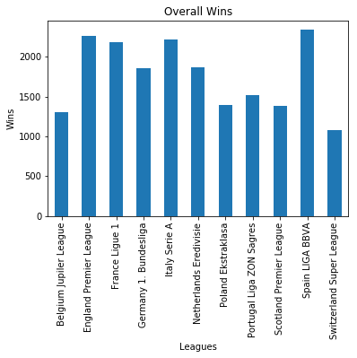

```python
#plot the overall wins
df_m.groupby('league')['winner'].count().plot(kind='bar', title='Overall Wins');
plt.xlabel('Leagues')
plt.ylabel('Wins')
```

Spain LIGA BBVA is the 1st with the highest number of wins, 2336. England Premier League is the 2nd with 2257 wins. Italy Serie A is the 3rd in rank with 2221 wins.

### Which teams in the 3 leagues won most of the games?

```python
#filter on the league that had the most wins and find the team
spain = df_m.query('country == "Spain"')
spain['winner'].value_counts()
```

```
8634     234
8633     228
9906     167
10267    142
8302     139
8315     122
10205    112
9864     106
8558      97
8305      94
8560      84
8581      69
8661      67
8371      67
8370      66
```

[output cut: 19 more lines]

```python
#find the team in the 2nd league ranked
england = df_m.query('country == "England"')
england['winner'].value_counts()
```

```
10260    192
8455     176
8456     175
9825     170
8586     151
8650     150
8668     121
10194     98
10252     86
10261     82
8654      80
8472      78
8659      75
9879      71
10003     62
```

[output cut: 20 more lines]

```python
#find the team in the 3rd league ranked
italy = df_m.query('country == "Italy"')
italy['winner'].value_counts()
```

```
9885      189
8686      162
8564      154
8636      154
9875      153
8535      132
8543      131
8600      115
10233     106
8540       91
8533       87
9882       84
8524       79
8529       76
10167      74
```

[output cut: 18 more lines]

1st team in Spain won 234 the games, 1st team in England won 192 games, 1st team in Italy won 189 games.

### Who is the most rated player?

```python
df_p.head()
```

|  | player_name | birthday | height | weight | id | player_api_id | overall_rating | potential | attacking_work_rate | defensive_work_rate | ... | vision | penalties | marking | standing_tackle | sliding_tackle | gk_diving | gk_handling | gk_kicking | gk_positioning | gk_reflexes |
| --- | --- | --- | --- | --- | --- | --- | --- | --- | --- | --- | --- | --- | --- | --- | --- | --- | --- | --- | --- | --- | --- |
| 0 | Aaron Appindangoye | 1992-02-29 00:00:00 | 182.88 | 187 | 1 | 505942 | 67.0 | 71.0 | medium | medium | ... | 54.0 | 48.0 | 65.0 | 69.0 | 69.0 | 6.0 | 11.0 | 10.0 | 8.0 | 8.0 |
| 1 | Aaron Cresswell | 1989-12-15 00:00:00 | 170.18 | 146 | 2 | 505942 | 67.0 | 71.0 | medium | medium | ... | 54.0 | 48.0 | 65.0 | 69.0 | 69.0 | 6.0 | 11.0 | 10.0 | 8.0 | 8.0 |
| 2 | Aaron Doran | 1991-05-13 00:00:00 | 170.18 | 163 | 3 | 505942 | 62.0 | 66.0 | medium | medium | ... | 54.0 | 48.0 | 65.0 | 66.0 | 69.0 | 6.0 | 11.0 | 10.0 | 8.0 | 8.0 |
| 3 | Aaron Galindo | 1982-05-08 00:00:00 | 182.88 | 198 | 4 | 505942 | 61.0 | 65.0 | medium | medium | ... | 53.0 | 47.0 | 62.0 | 63.0 | 66.0 | 5.0 | 10.0 | 9.0 | 7.0 | 7.0 |
| 4 | Aaron Hughes | 1979-11-08 00:00:00 | 182.88 | 154 | 5 | 505942 | 61.0 | 65.0 | medium | medium | ... | 53.0 | 47.0 | 62.0 | 63.0 | 66.0 | 5.0 | 10.0 | 9.0 | 7.0 | 7.0 |

5 rows × 43 columns

```python
#average rating
df_p['overall_rating'].mean()
```

```
68.571993379919093
```

```python
#count players above average rating
above = df_p.query('overall_rating > overall_rating.mean()')
above['overall_rating'].count()
```

```
5700
```

```python
#count players below average rating
below = df_p.query('overall_rating < overall_rating.mean()')
below['overall_rating'].count()
```

```
5176
```

```python
#the most rated player
above.max()
```

[output not shown]

The most rated player is dos Santos Fabio Junior with a 91 overall rating.

### What are the attributes that contribute to the players' overall rating?

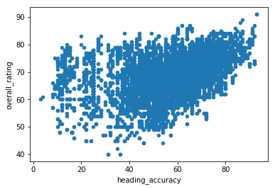

```python
#relationship between rating and heading accuracy
df_p.plot(x='heading_accuracy', y='overall_rating', kind='scatter');
```

There is a positive correlation between heading accuracy and overall rating.

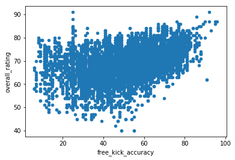

```python
#relationship between rating and free kick accuracy
df_p.plot(x='free_kick_accuracy', y='overall_rating', kind='scatter');
```

Free kick accuracy doesn't have a strong impact in overall rating.

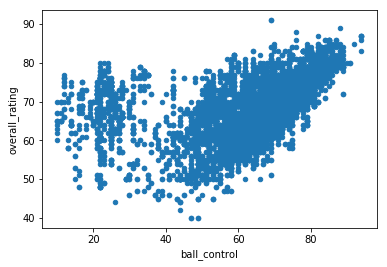

```python
#relationship between rating and ball control
df_p.plot(x='ball_control', y='overall_rating', kind='scatter');
```

There is a strong positive correlation between overall rating and ball control.

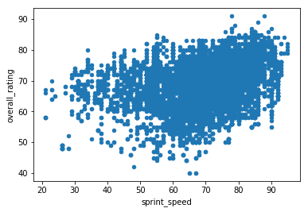

```python
#relationship between rating and sprint speed
df_p.plot(x='sprint_speed', y='overall_rating', kind='scatter');
```

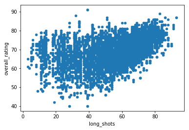

```python
#relationship between rating and long shots
df_p.plot(x='long_shots', y='overall_rating', kind='scatter');
```

Positive correlation between long shots and overall rating.

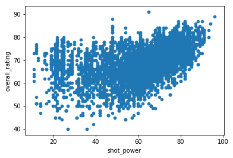

```python
#relationship between rating and shot power
df_p.plot(x='shot_power', y='overall_rating', kind='scatter');
```

Strong correlation between shot power and overall rating.

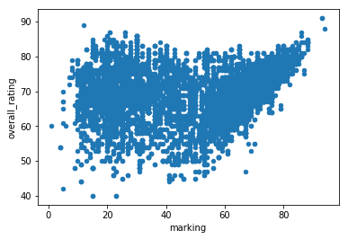

```python
#relationship between rating and marking
df_p.plot(x='marking', y='overall_rating', kind='scatter');
```

We can't say there is a positive correlation between marking and overall rating.

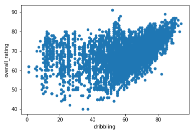

```python
#relationship between rating and dribbling
df_p.plot(x='dribbling', y='overall_rating', kind='scatter');
```

Strong positive correlation between overall rating and dribbling.

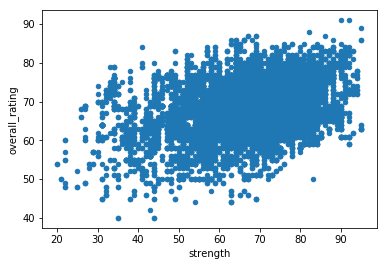

```python
#relationship between rating and strength
df_p.plot(x='strength', y='overall_rating', kind='scatter');
```

Strong positive correlation between strength and overall rating.

#### The attributes that count towards overall rating of the players are: heading accuracy, ball control, sprint speed, long shots, shot power, dribbling and strength.

### What team attributes lead to the most victories?

```python
df_t.head(1)
```

|  | team_api_id | buildUpPlaySpeed | buildUpPlaySpeedClass | buildUpPlayDribbling | buildUpPlayDribblingClass | buildUpPlayPassing | buildUpPlayPassingClass | buildUpPlayPositioningClass | chanceCreationPassing | chanceCreationPassingClass | ... | chanceCreationShooting | chanceCreationShootingClass | chanceCreationPositioningClass | defencePressure | defencePressureClass | defenceAggression | defenceAggressionClass | defenceTeamWidth | defenceTeamWidthClass | defenceDefenderLineClass |
| --- | --- | --- | --- | --- | --- | --- | --- | --- | --- | --- | --- | --- | --- | --- | --- | --- | --- | --- | --- | --- | --- |
| 1 | 9930 | 52 | Balanced | 48.0 | Normal | 56 | Mixed | Organised | 54 | Normal | ... | 64 | Normal | Organised | 47 | Medium | 44 | Press | 54 | Normal | Cover |

1 rows × 22 columns

```python
#check attributes of the best team in Spain
best_team_spain = df_t.query('team_api_id == 8634')
best_team_spain
```

|  | team_api_id | buildUpPlaySpeed | buildUpPlaySpeedClass | buildUpPlayDribbling | buildUpPlayDribblingClass | buildUpPlayPassing | buildUpPlayPassingClass | buildUpPlayPositioningClass | chanceCreationPassing | chanceCreationPassingClass | ... | chanceCreationShooting | chanceCreationShootingClass | chanceCreationPositioningClass | defencePressure | defencePressureClass | defenceAggression | defenceAggressionClass | defenceTeamWidth | defenceTeamWidthClass | defenceDefenderLineClass |
| --- | --- | --- | --- | --- | --- | --- | --- | --- | --- | --- | --- | --- | --- | --- | --- | --- | --- | --- | --- | --- | --- |
| 122 | 8634 | 35 | Balanced | 35.0 | Normal | 32 | Short | Free Form | 37 | Normal | ... | 35 | Normal | Free Form | 61 | Medium | 63 | Press | 65 | Normal | Cover |
| 123 | 8634 | 36 | Balanced | 35.0 | Normal | 51 | Mixed | Free Form | 36 | Normal | ... | 56 | Normal | Free Form | 61 | Medium | 65 | Press | 65 | Normal | Cover |

2 rows × 22 columns

```python
#check attributes of the best team in England
best_team_england = df_t.query('team_api_id == 10260')
best_team_england
```

|  | team_api_id | buildUpPlaySpeed | buildUpPlaySpeedClass | buildUpPlayDribbling | buildUpPlayDribblingClass | buildUpPlayPassing | buildUpPlayPassingClass | buildUpPlayPositioningClass | chanceCreationPassing | chanceCreationPassingClass | ... | chanceCreationShooting | chanceCreationShootingClass | chanceCreationPositioningClass | defencePressure | defencePressureClass | defenceAggression | defenceAggressionClass | defenceTeamWidth | defenceTeamWidthClass | defenceDefenderLineClass |
| --- | --- | --- | --- | --- | --- | --- | --- | --- | --- | --- | --- | --- | --- | --- | --- | --- | --- | --- | --- | --- | --- |
| 810 | 10260 | 46 | Balanced | 34.0 | Normal | 54 | Mixed | Organised | 49 | Normal | ... | 56 | Normal | Organised | 42 | Medium | 41 | Press | 56 | Normal | Cover |
| 811 | 10260 | 38 | Balanced | 42.0 | Normal | 44 | Mixed | Organised | 49 | Normal | ... | 40 | Normal | Organised | 54 | Medium | 53 | Press | 56 | Normal | Cover |

2 rows × 22 columns

```python
#check attributes of the best team in Italy
best_team_italy = df_t.query('team_api_id == 9885')
best_team_italy
```

|  | team_api_id | buildUpPlaySpeed | buildUpPlaySpeedClass | buildUpPlayDribbling | buildUpPlayDribblingClass | buildUpPlayPassing | buildUpPlayPassingClass | buildUpPlayPositioningClass | chanceCreationPassing | chanceCreationPassingClass | ... | chanceCreationShooting | chanceCreationShootingClass | chanceCreationPositioningClass | defencePressure | defencePressureClass | defenceAggression | defenceAggressionClass | defenceTeamWidth | defenceTeamWidthClass | defenceDefenderLineClass |
| --- | --- | --- | --- | --- | --- | --- | --- | --- | --- | --- | --- | --- | --- | --- | --- | --- | --- | --- | --- | --- | --- |
| 628 | 9885 | 26 | Slow | 47.0 | Normal | 24 | Short | Organised | 64 | Normal | ... | 72 | Lots | Organised | 23 | Deep | 67 | Double | 36 | Normal | Cover |
| 629 | 9885 | 50 | Balanced | 35.0 | Normal | 20 | Short | Organised | 65 | Normal | ... | 80 | Lots | Organised | 35 | Medium | 65 | Press | 35 | Normal | Cover |

2 rows × 22 columns

```python
#merge dataframes
best_teams = best_team_spain.append(best_team_england, ignore_index=True)
best_teams = best_teams.append(best_team_italy, ignore_index=True)
best_teams.head(6)
```

|  | team_api_id | buildUpPlaySpeed | buildUpPlaySpeedClass | buildUpPlayDribbling | buildUpPlayDribblingClass | buildUpPlayPassing | buildUpPlayPassingClass | buildUpPlayPositioningClass | chanceCreationPassing | chanceCreationPassingClass | ... | chanceCreationShooting | chanceCreationShootingClass | chanceCreationPositioningClass | defencePressure | defencePressureClass | defenceAggression | defenceAggressionClass | defenceTeamWidth | defenceTeamWidthClass | defenceDefenderLineClass |
| --- | --- | --- | --- | --- | --- | --- | --- | --- | --- | --- | --- | --- | --- | --- | --- | --- | --- | --- | --- | --- | --- |
| 0 | 8634 | 35 | Balanced | 35.0 | Normal | 32 | Short | Free Form | 37 | Normal | ... | 35 | Normal | Free Form | 61 | Medium | 63 | Press | 65 | Normal | Cover |
| 1 | 8634 | 36 | Balanced | 35.0 | Normal | 51 | Mixed | Free Form | 36 | Normal | ... | 56 | Normal | Free Form | 61 | Medium | 65 | Press | 65 | Normal | Cover |
| 2 | 10260 | 46 | Balanced | 34.0 | Normal | 54 | Mixed | Organised | 49 | Normal | ... | 56 | Normal | Organised | 42 | Medium | 41 | Press | 56 | Normal | Cover |
| 3 | 10260 | 38 | Balanced | 42.0 | Normal | 44 | Mixed | Organised | 49 | Normal | ... | 40 | Normal | Organised | 54 | Medium | 53 | Press | 56 | Normal | Cover |
| 4 | 9885 | 26 | Slow | 47.0 | Normal | 24 | Short | Organised | 64 | Normal | ... | 72 | Lots | Organised | 23 | Deep | 67 | Double | 36 | Normal | Cover |
| 5 | 9885 | 50 | Balanced | 35.0 | Normal | 20 | Short | Organised | 65 | Normal | ... | 80 | Lots | Organised | 35 | Medium | 65 | Press | 35 | Normal | Cover |

6 rows × 22 columns

### Limitations and Challenges

During the analysis of this project I faced many limitations and challenges due to the fact that the data was very inaccurate.

The name of the players were incomplete, some of them didn't have any last names, just first names, and also some of them were missing completely. Moreover, I couldn't link the players to the teamsas there was no correlation between them.

The team names were missing, so the analysis was based only on IDs and due to this I cannot show a clear image on which are the teams I relate to.

## Conclusions

I have found that the best leagues in Europe during 2008-2016 are Spain, England and Italy. The best teams have won around 200 games over this period.

The average rating of a player is 68 and there are more players above average than below average. The attributes that count towards this rating of the players are: heading accuracy, ball control, sprint speed, long shots, shot power, dribbling and strength.

```python
from subprocess import call
call(['python', '-m', 'nbconvert', 'Investigate_a_Dataset.ipynb'])
```